# Lab 4: Spatial Data with Denny’s and La Quinta

Nate Smullen

10/16/2022

Visualizing spatial data

##Load Packages

```r
library(tidyverse)
library(dsbox)
```

##Load States Data

```r
states <- read_csv("states.csv")
```

```r
nrow(dennys)
```

```
[1] 1643
```

```r
ncol(dennys)
```

```
[1] 8
```

```r
names(dennys)
```

```
[1] "address"       "city"          "state"         "zip"           "longitude"     "latitude"      "country"       "establishment"
```

```r
nrow(laquinta)
```

```
[1] 895
```

```r
ncol(laquinta)
```

```
[1] 8
```

```r
names(laquinta)
```

```
[1] "address"       "city"          "state"         "zip"           "longitude"     "latitude"      "country"       "establishment"
```

3. There are several LaQuinta’s locations outside of the US. There are some in Canada, Mexico, China, New Zealand, Turkey, United Arab Emirates, Chile, and Columbia. There are no Denny’s locations listed on the website that are outside of the US.
4. The locations outside of the US still have a value in the state column, so you cannot filter by null values in that column. You could check to make sure each state is actually a state in the US, however the state abbreviation for a location in a different country may be the same as one in the US. Instead, you could try to filter by zip codes that are in the US. Zip codes, however, are not unique globally, so you could run into the issue where a foreign zip code matches one in the US. Therefore, the safest way to determine if a state is in the US is to filter based on combinations of longitudes and latitudes that are inside of the US.

```r
dennys %>%
  filter(!(state %in% states$abbreviation))
```

| address | city | state | zip | longitude | latitude | country | establishment |
| --- | --- | --- | --- | --- | --- | --- | --- |

The Denny’s dataset filtered by states not in the US is empty, meaning there are no locations outside of the US.

```r
dennys <- dennys %>%
  mutate(country = "United States")
```

```r
laquinta %>%
  filter(!(state %in% states$abbreviation))
```

[output not shown]

```r
laquinta <- laquinta %>%
  mutate(country = case_when(
    state %in% state.abb     ~ "United States",
    state %in% c("ON", "BC") ~ "Canada",
    state == "ANT"           ~ "Colombia",
    state %in% c("AG" ,"QR","CH","NL","VE","PU","SL") ~ "Mexico",
    state == "FM"            ~ "Honduras"))
```

```r
laquinta <- laquinta %>%
  filter(country == "United States")
```

```r
dennys %>%
  count(state) %>%
  inner_join(states, by = c("state" = "abbreviation"))
```

| state | n | name | area |
| --- | --- | --- | --- |
| AK | 3 | Alaska | 665384.04 |
| AL | 7 | Alabama | 52420.07 |
| AR | 9 | Arkansas | 53178.55 |
| AZ | 83 | Arizona | 113990.30 |
| CA | 403 | California | 163694.74 |
| CO | 29 | Colorado | 104093.67 |
| CT | 12 | Connecticut | 5543.41 |
| DC | 2 | District of Columbia | 68.34 |
| DE | 1 | Delaware | 2488.72 |
| FL | 140 | Florida | 65757.70 |

[output cut: 41 more lines]

```r
dennys <- dennys %>%
  mutate(establishment = "Denny's")
laquinta <- laquinta %>%
  mutate(establishment = "La Quinta")
```

```r
dn_lq <- bind_rows(dennys, laquinta)
```

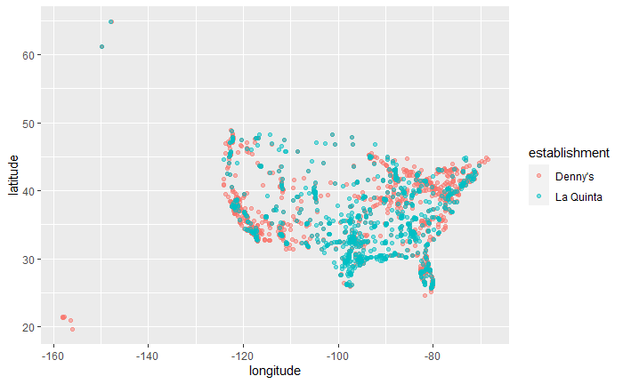

```r
ggplot(dn_lq, mapping = aes(x = longitude, y = latitude, color = establishment)) +
  geom_point(alpha = .5)
```

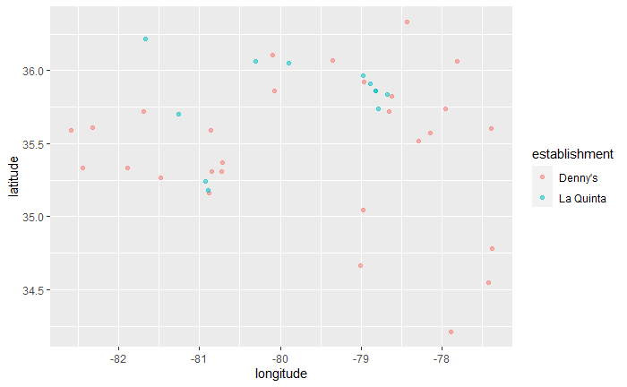

```r
dn_lq_nc = dn_lq %>% filter(state == "NC")

ggplot(dn_lq_nc, mapping = aes(x = longitude, y = latitude, color = establishment)) +
  geom_point(alpha = .5)
```

Visually, Mitch Hedberg’s joke does not hold in North Carolina

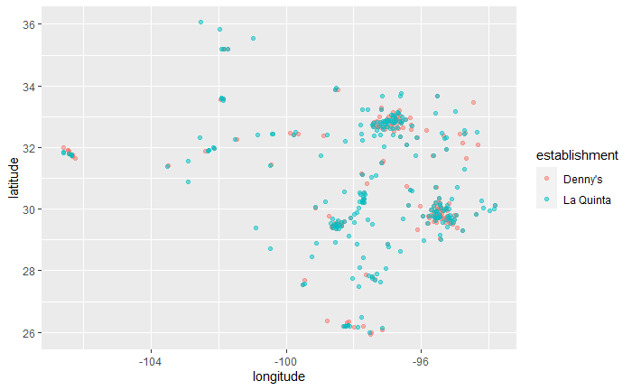

```r
dn_lq_nc = dn_lq %>% filter(state == "TX")

ggplot(dn_lq_nc, mapping = aes(x = longitude, y = latitude, color = establishment)) +
  geom_point(alpha = .5)
```

Visually, Mitch Hedberg’s joke holds in Texas.